# Bayesian mixed models with brms | session 1

Last updated: 2021-04-14

## Outline

## Outline

- Advantages of Bayesian inference
- Difference to (classical) frequentist approaches
- Fitting and comparing frequentist and Bayesian LMMs
- Evaluating a Bayesian model and model parameters
- There will be exercises (i.e. time for questions)!

## Before we start …

- Download the workshop folder.
- We will pull it from GitHub via RStudio.
- Open RStudio
- Link for workshop folder.
- Exercise scripts
- Data
- Slides
- Create a folder called “stanout”

## Two universes

## Two universes

- **Null-hypothesis significance testing (NHST)**
- **Bayesian statistics**
- The difference is the way we use to arrive at our inference.
- NHST: do we believe in the data if there’s actually no effect?
- Bayesian: what’s the probability of an effect given the data (and what we know from similar data)?

## Null-hypothesis significance testing (NHST)

\[ P(\text{data} \mid H_0 = \text{TRUE}) \]

- aka Frequentist statistics
- Inference: evaluating the probability of data assuming that the null hypothesis is true.
- If the data are extreme enough, the null hypothesis becomes implausible.
- Conclusion: the alternative hypothesis is assumed if the null hypothesis was rejected.
- Data are variable and parameters are fixed

## NHST and its problems

- Intuitive statistical significance is not a binary but continuous property
- *p*-values vs parameter estimation and Bayes Factors (compare probability models rather than testing against the null)
- What are you doing if *p*-value\(=0.051\)?
- Trade-off small difference sample size
- Stopping rule
- Inference is based on a large number of fictional replications.
- \(\alpha\)-level of 0.05 implies that 5% of replications will:
  - detect an effect that isn’t real
  - do not detect and effect that is real

## Convergence failure for lmer models

- Maximal random effects structure (Baayen et al., 2008; Barr et al., 2013)
- (g)lmer fail to convergence
- Overparametrisation: unidentifiable parameter estimates (Bates et al., 2015)
- Solutions: reducing model complexity, changing optimisers
- The argument favouring a model becomes the failure to fit a possibly better model
- Certain sources of random errors are not addressed

## Why Bayesian?

It tells us what we want to know!

Given the data (and our prior knowledge),

- What interval contains an unobserved parameter with .95 (or some other) probability?
- What’s the relative weight of evidence for one model (e.g., ‘null’) vs. another (e.g., an alternative)?

## Why Bayesian?

\[ p(H_0 = \text{TRUE} \mid \text{data})\\ \text{or}\\ p(H_1 = \text{TRUE} \mid \text{data})\\ \text{or}\\ p(H_1 = \text{FALSE} \mid \text{data})\\ \]

- Estimate credibility over parameter values based on the observed data (Kruschke, 2014).
- Given the data, what parameter values should we believe in with most confidence.
- For this we need to start with (1) a probability model and (2) *prior* expectation as to the parameter values of this model.

## Bayesian estimation

### Bayes’ Theorem

\[ p(\theta \mid y) \propto p(\theta) \cdot p(y \mid \theta) \] - \(\theta\) = parameter(s), \(y\) = data, \(\mid\) = given (conditional on), \(\propto\) = proportional to - \(p(y \mid \theta)\) = likelihood (probability of each data point given parameter value estimates) - \(p(\theta)\) = prior (what do we know about the parameter(s)) - \(p(\theta \mid y)\) = posterior distribution (how much we believe in different parameter values after seeing the data)

[figure not shown]

## Bayesian estimation

### Bayes’ Theorem

\[ p(\theta \mid y) \propto p(\theta)p(y \mid \theta) \]

- The posterior is proportional to the prior times the likelihood.
- In maximum likelihood estimation we search for the parameters that maximize the (log) likelihood.
- For Bayesian estimation we use the likelihood to update our prior beliefs in different parameter values.
- Data are fixed and parameters are variable.
- Bayes’ Theorem allows us to determine parameter values from the data (plus prior).
- This can be computationally demanding!

[figure not shown]

## brms (Bürkner, 2017)

- *R* package for Bayesian models
- More probability models than other regressions packages
  - gaussian, lognormal, bernoulli, poisson, zero_inflated_poisson, skew_normal, shifted_lognormal, exgaussian, *et cetera*
  - and allows probabilistic mixture models, nonlinear regression models, equal variance signal-detection theory
- Under the hood: brms creates Stan code to compile an MCMC (Markov Chain Monte Carlo) sampler
- Compiling the sampler and for the sampler to obtain the full posterior takes times.
- Check and cite the tutorials of brms author Paul-Christian Bürkner’s (Bürkner, 2017, 2018, 2019; Bürkner & Vuorre, 2019)

## Why is this important for linguistis?

- Beliefs about the hypothesis are directly based on the data as a probability distribution.
- Useful for small data sets in which prior information might play a huge role.
- Model many different data types (keystroke latencies, number of pauses, accuracy).
- Flexible ways of modelling data and deriving inference.
- Posterior sampling can handle missing data problems.

## Simulating data

```r
data <- jens_data_machine(intercept = 300, slope = 15)
```

| participant_id | trial_id | condition | y |
| --- | --- | --- | --- |
| 1 | 1 | a | 146.77 |
| 1 | 3 | a | 253.43 |
| 1 | 5 | a | 364.75 |
| 1 | 7 | a | 352.91 |
| 1 | 9 | a | 299.22 |
| 1 | 2 | b | 351.40 |
| 1 | 4 | b | 276.41 |
| 1 | 6 | b | 438.49 |
| 1 | 8 | b | 303.78 |
| 1 | 10 | b | 345.09 |
| 2 | 1 | a | 238.09 |
| 2 | 3 | a | 264.87 |
| 2 | 5 | a | 150.96 |
| 2 | 7 | a | 327.69 |
| 2 | 9 | a | 326.53 |
| 2 | 2 | b | 275.00 |
| 2 | 4 | b | 349.95 |
| 2 | 6 | b | 398.78 |
| 2 | 8 | b | 386.37 |
| 2 | 10 | b | 413.74 |
| 3 | 1 | a | 394.93 |
| 3 | 3 | a | 348.40 |
| 3 | 5 | a | 268.00 |
| 3 | 7 | a | 377.94 |
| 3 | 9 | a | 202.57 |
| 3 | 2 | b | 293.61 |
| 3 | 4 | b | 375.91 |
| 3 | 6 | b | 450.01 |
| 3 | 8 | b | 556.62 |
| 3 | 10 | b | 300.41 |

[output cut: 270 more lines]

## Simulating data

```r
data <- jens_data_machine(intercept = 300, slope = 15)
```

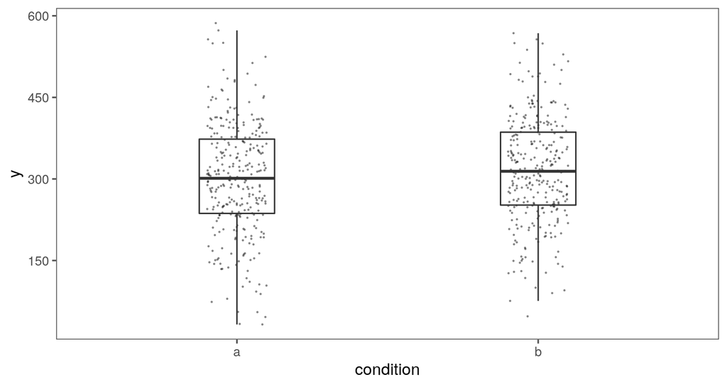

- Think about it as keystroke intervals :)
- Parameter of interest: difference between conditions.
- After accounting for variability in the data associated with the sampling process.
- Mixed-effects model combine fixed and random effects.

## Simulating data

```r
data <- jens_data_machine(intercept = 300, slope = 15)
```

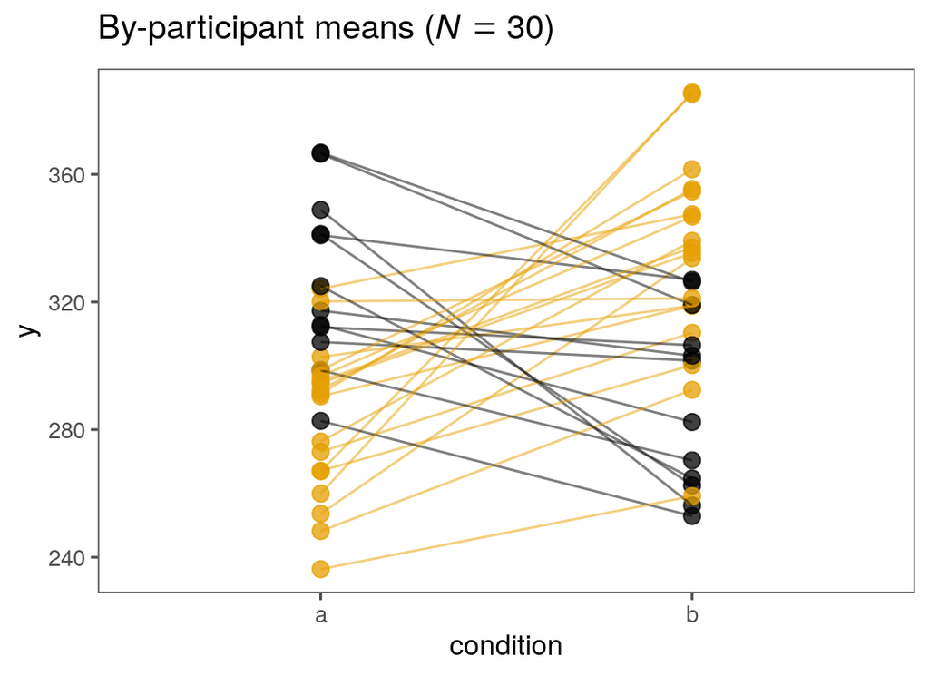

## Formulating the model

\[ y_i \sim N(\mu_i, \sigma^2)\\ \mu_i = \beta_0 + \text{condition}_i\cdot\beta_1 + u_i\\ \]

- Outcome variable \(y\)
- Tilde symbol (\(\sim\)) represents “is a function of” or “comes from”
- Equal sign (\(=\)) is used for deterministic relationships
- \(N\) is a Gaussian normal distribution with a mean \(\mu\) and a residual (error) variance \(\sigma^2\)
- Greek symbols are used for population values (with caret for estimates, e.g. \(\hat{\beta}\))

## Formulating the model

\[ y_i \sim N(\mu_i, \sigma^2)\\ \mu_i = \beta_0 + \text{condition}_i\cdot\beta_1 + u_i\\ \]

- Treatment contrast: condition *a* = 0, condition *b* = 1

```r
contrasts(factor(data$condition)) # default contrast
```

```
  b
a 0
b 1
```

- We assume an additive normal probability model (likelihood).
- Given the data \(y\) and this model, we can estimate \(\beta_0\) and \(\beta_1\) (for a Bayesian model we still need priors.)
- Intercept \(\beta_0\): estimated mean of condition *a* (you see why?)
- Slope \(\beta_1\): difference between condition *a* and condition *b*
- \(u\) is participant variance with \(N(0,\sigma_u)\)

## *R*-syntax

- Frequentist mixed-effects models

```r
library(lme4)
fit_lmer <- lmer(y ~ 1 + condition + (1|participant_id), data = data)
```

- Bayesian mixed-effects models

```r
library(brms)
fit_brm <- brm(y ~ 1 + condition + (1|participant_id), data = data)
```

## Exercise: fit models on simulated data

- Complete and run script `lmer_sim.R` and `brms_sim.R`
- Replace `---` correctly; run the script carefully line by line and check the output in the console.
- Inspect and compare the fixed effects summaries.

## Fit models on simulated data

```r
data <- jens_data_machine(intercept = 300, slope = 15)
```

```r
fit_lmer <- lmer(y ~ 1 + condition + (1|participant_id), data = data)
```

```r
fit_brm <- brm(y ~ 1 + condition + (1|participant_id), data = data)
```

## Fit models on simulated data

```r
data <- jens_data_machine(intercept = 300, slope = 15)
```

```r
coef(summary(fit_lmer)) # Coefficients of frequentist model
```

```
             Estimate Std. Error   t value
(Intercept) 300.26567   5.789763 51.861484
conditionb   15.59151   8.136926  1.916143
```

```r
fixef(fit_brm) # Coefficients of Bayesian model
```

```
            Estimate Est.Error        Q2.5     Q97.5
Intercept  300.16663  5.988561 288.8796244 311.79417
conditionb  15.76034  8.047246  -0.0991772  31.46148
```

## So what about this?

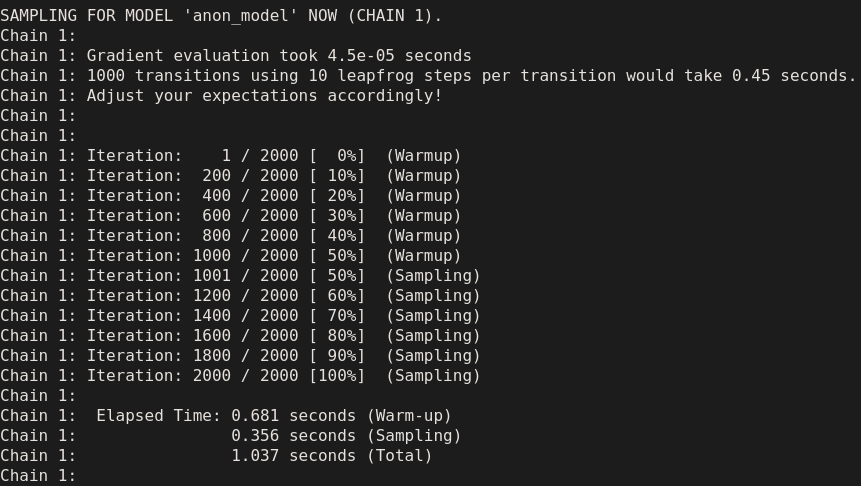

- 2,000 iterations for parameter estimation per chain
- `iterations / 2` warm-up samples: discarded eventually
- 4 chains to establish convergence
- Parallelize chains by changing `cores` (check `parallel::detectCores()`)
- How many posterior samples have we got for our inference (`= chains * (iterations - warm-up)`)?
- How many iterations / chains do you need?
- Check [this link](https://www.barelysignificant.com/slides/RGUG2019#38)

## Parameter estimation

- **Hamiltonian Monte Carlo:** Markov chain Monte Carlo method for obtaining random samples.
- Converge to being distributed according to a target probability distribution.
- Probability of values proposed by the sampler is estimated given the data and the prior.
- Direction changes if probability of proposed estimate is lower than previous one.
- Priors can be used to limit the parameter space (which is otherwise infinite) but are updated at every step.
- Parameter space is really multi-dimensional.

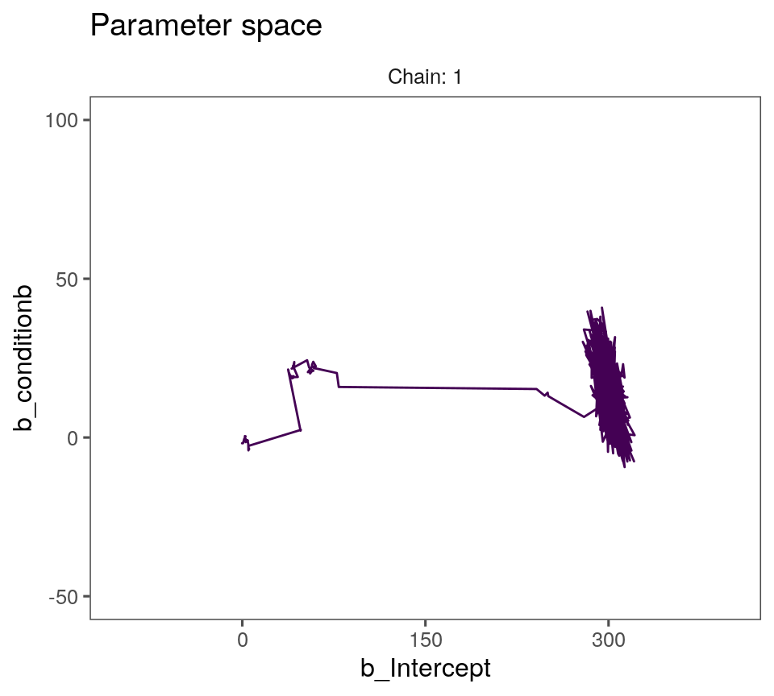

## Parameter estimation

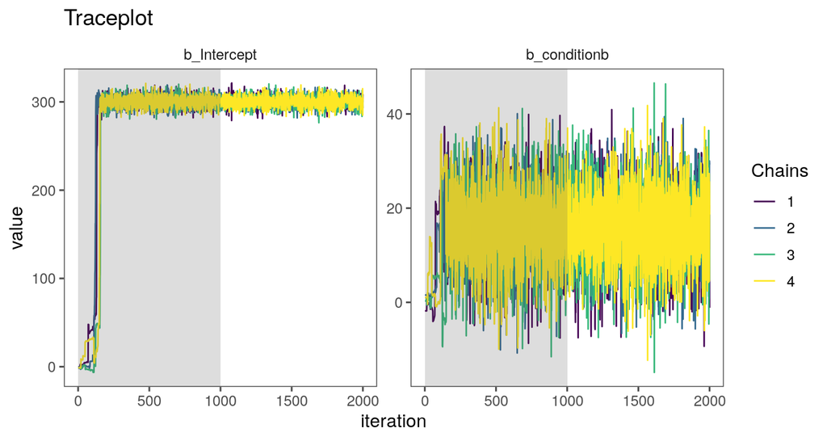

## Parameter estimation

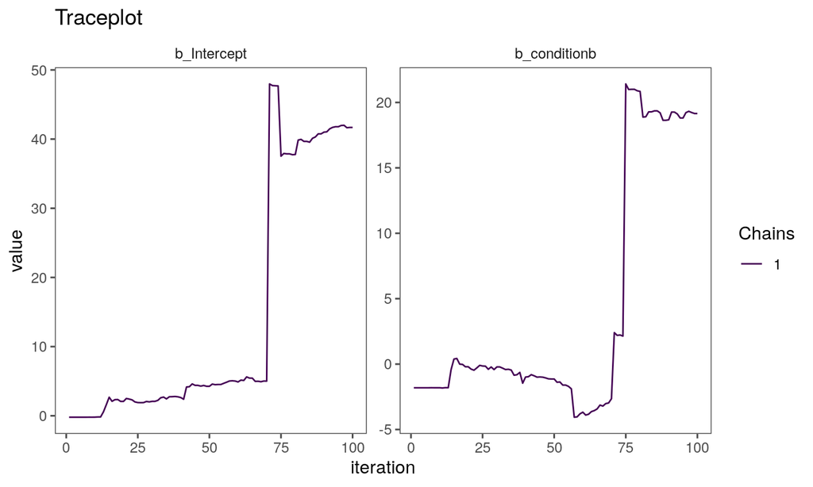

## Parameter estimation

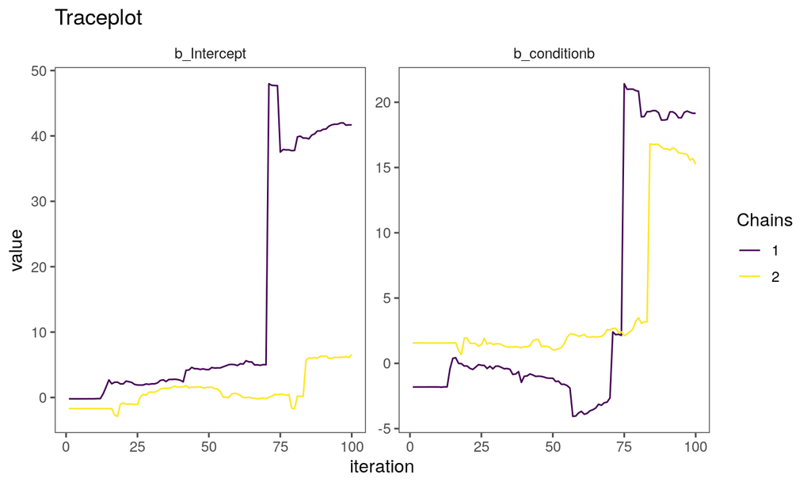

## Parameter estimation

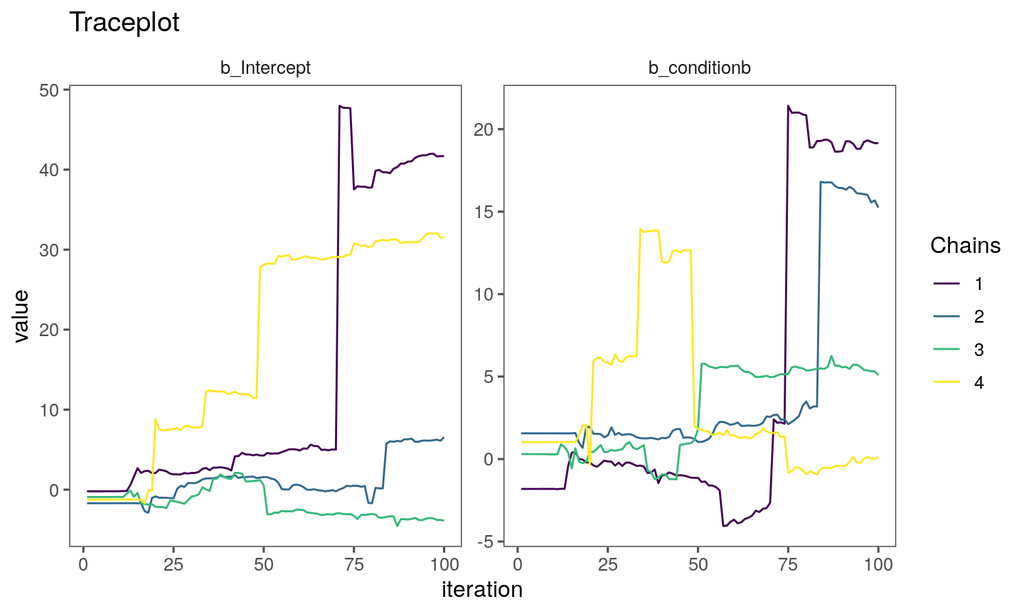

## Parameter estimation

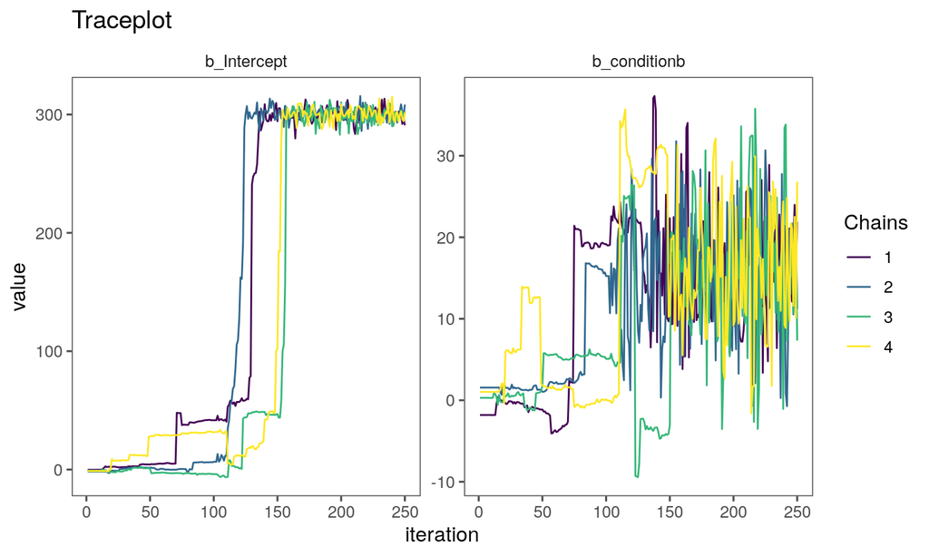

## Parameter estimation

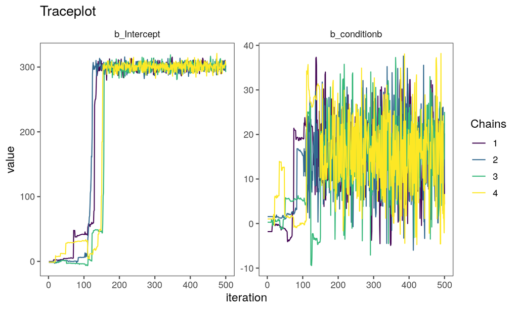

## Parameter estimation

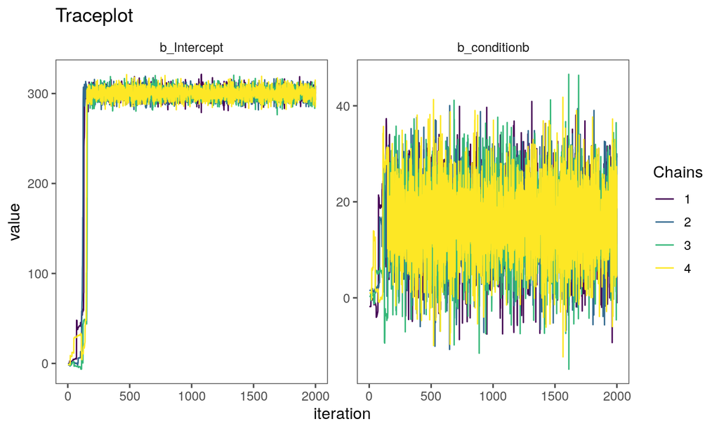

## Parameter estimation

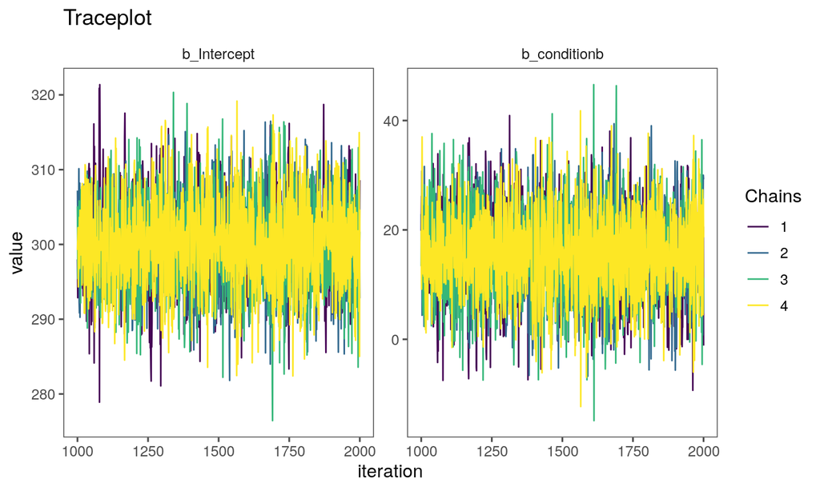

## Model diagnostics

- \(\hat{R}\) (*R*-hat) convergence statistic; should be $<$1.1 (Gelman & Rubin, 1992)

```r
rhat(fit_brm, pars = c("b_Intercept", "b_conditionb"))
```

- Traceplots: we want fat hairy caterpillars

```r
plot(fit_brm, pars = c("b_Intercept", "b_conditionb"))
```

- Posterior predictive checks: compare observed data \(y\) and model predictions \(y_{rep}\)

```r
pp_check(fit_brm, nsamples = 100)
```

## Exercise: model diagnostics

- Open the scripts `model_diagnostics.R`
- Replace the `---`s appropriately.
- Run the code (line by line)

## Posterior: probability distribution

- Get posterior of slope \(\beta\) (difference between conditions)

```r
beta <- posterior_samples(fit_brm, pars = "b_conditionb") %>% pull()
length(beta)
```

```
[1] 4000
```

```r
beta[1:5]
```

```
[1] 26.169134 20.234850  9.773276 21.438894 12.943398
```

## Posterior: probability distribution

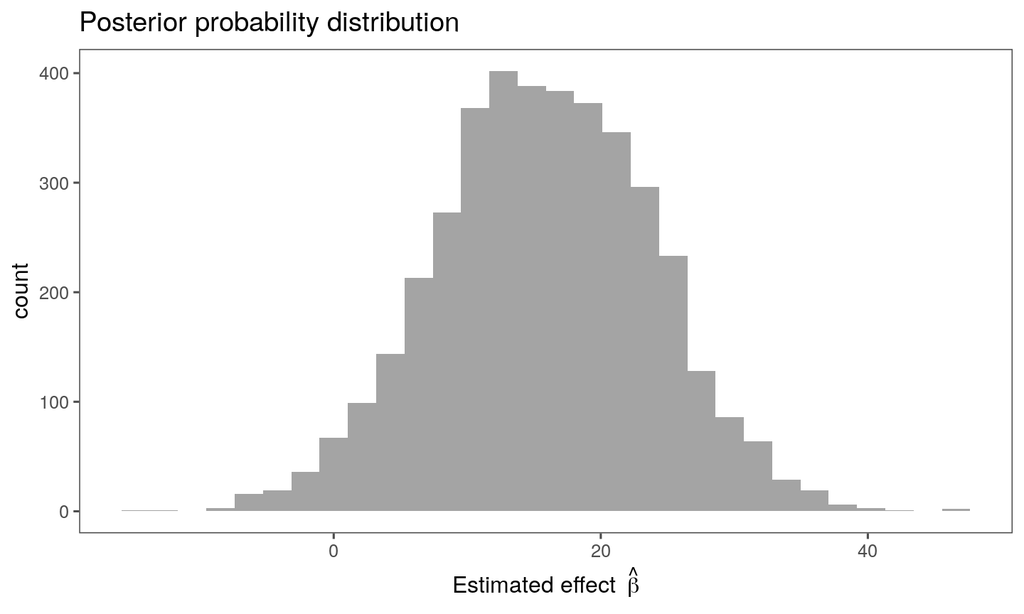

## Posterior: probability distribution

- Posterior mean

```r
mean(beta)
```

```
[1] 15.76034
```

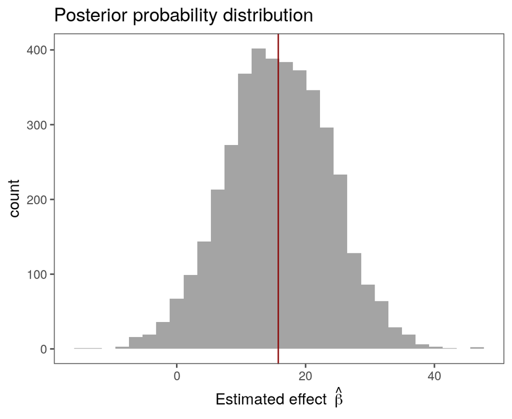

## Posterior: probability distribution

- 95% probability interval (conceptually different from confidence interval)

```r
quantile(beta, probs = c(0.025, 0.975))
```

```
      2.5%      97.5%
-0.0991772 31.4614818
```

- 89% probability interval (McElreath, 2016)

```r
quantile(beta, probs = c(0.055, 0.945))
```

```
     5.5%     94.5%
 2.804782 28.344642
```

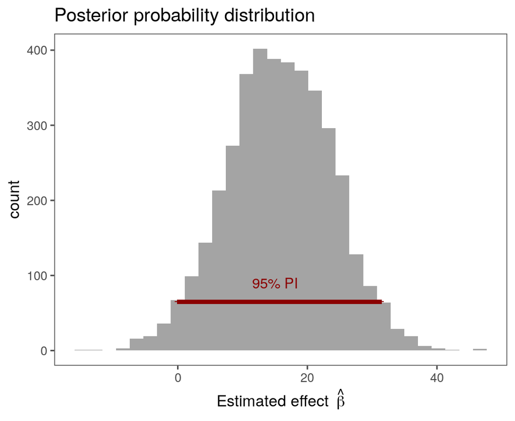

## Posterior: probability distribution

- 95% probability interval (conceptually different from confidence interval)

```r
quantile(beta, probs = c(0.025, 0.975))
```

```
      2.5%      97.5%
-0.0991772 31.4614818
```

- 89% probability interval (McElreath, 2016)

```r
quantile(beta, probs = c(0.055, 0.945))
```

```
     5.5%     94.5%
 2.804782 28.344642
```

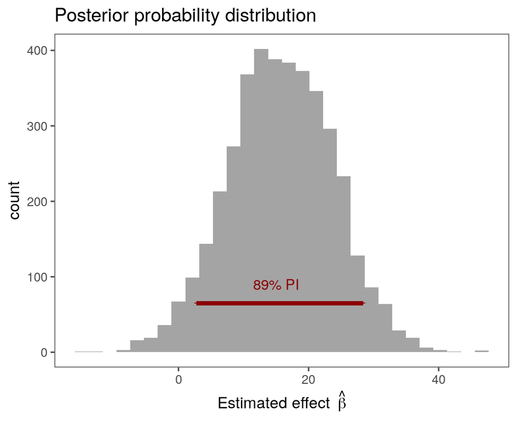

## Posterior: probability distribution

- Probability that slope \(\beta\) is negative: \(P(\hat{\beta}<0)\)

```r
mean(beta < 0)
```

```
[1] 0.02775
```

- Probability that slope \(\beta\) is smaller than 10: \(P(\hat{\beta}<10)\)

```r
mean(beta < 10)
```

```
[1] 0.23375
```

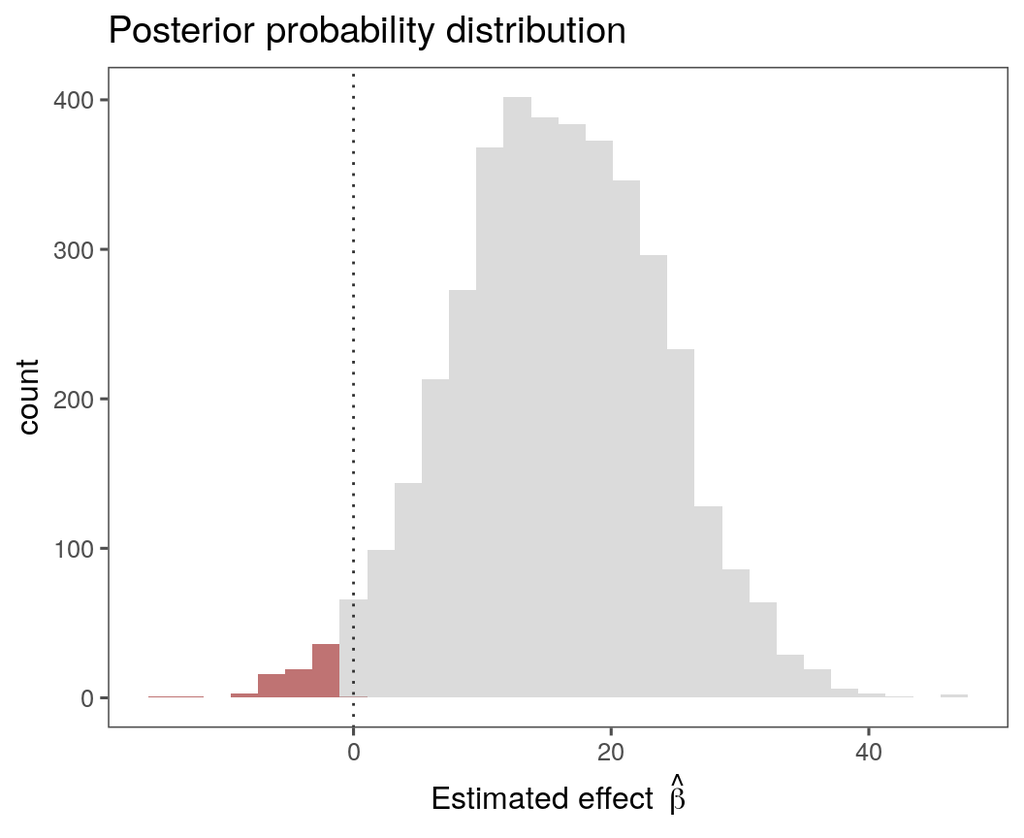

## Posterior: probability distribution

- Probability that slope \(\beta\) is negative: \(P(\hat{\beta}<0)\)

```r
mean(beta < 0)
```

```
[1] 0.02775
```

- Probability that slope \(\beta\) is smaller than 10: \(P(\hat{\beta}<10)\)

```r
mean(beta < 10)
```

```
[1] 0.23375
```

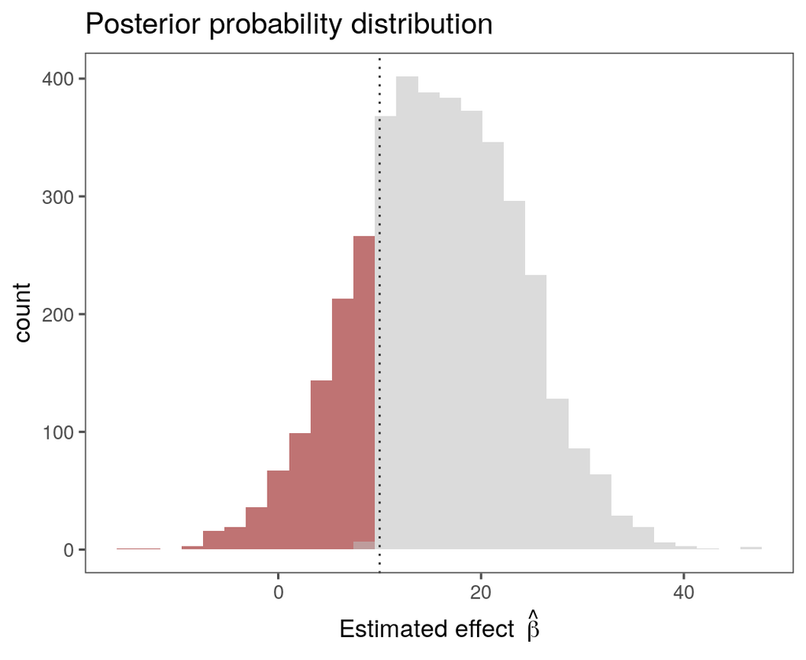

## ROPE

- Region of practical equivalence: range of values that are practically equivalent (Kruschke, 2010, 2011).
- Point values don’t represent our beliefs about what the null hypothesis is like: \(H_0 = 0\)
- The ROPE is the range of values that are practically equivalent to a null effect.
- Define region that is equivalent to no effect: all values in interval [-5, 5]

## ROPE

- Region of practical equivalence: range of values that are practically equivalent (Kruschke, 2010, 2011).
- Point values don’t represent our beliefs about what the null hypothesis is like: \(H_0 = 0\)
- The ROPE is the range of values that are practically equivalent to a null effect.
- Define region that is equivalent to no effect: all values in interval [-5, 5]

```r
library(bayestestR)
rope(beta, range = c(-5, 5))
```

```
# Proportion of samples inside the ROPE [-5.00, 5.00]:

inside ROPE
-----------
4.18 %
```

## ROPE

- Region of practical equivalence: range of values that are practically equivalent (Kruschke, 2010, 2011).
- Point values don’t represent our beliefs about what the null hypothesis is like: \(H_0 = 0\)
- The ROPE is the range of values that are practically equivalent to a null effect.
- Define region that is equivalent to no effect: all values in interval [-5, 5]

```r
library(bayestestR)
rope(beta, range = c(-5, 5))
```

```
# Proportion of samples inside the ROPE [-5.00, 5.00]:

inside ROPE
-----------
4.18 %
```

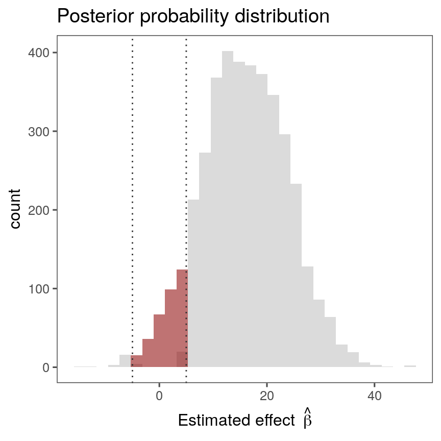

## ROPE

- Region of practical equivalence: range of values that are practically equivalent (Kruschke, 2010, 2011).
- Point values don’t represent our beliefs about what the null hypothesis is like: \(H_0 = 0\)
- The ROPE is the range of values that are practically equivalent to a null effect.
- Define region that is equivalent to no effect: all values in interval [-Inf, 5]

```r
library(bayestestR)
rope(beta, range = c(-Inf, 5))
```

```
# Proportion of samples inside the ROPE [-Inf, 5.00]:

inside ROPE
-----------
4.18 %
```

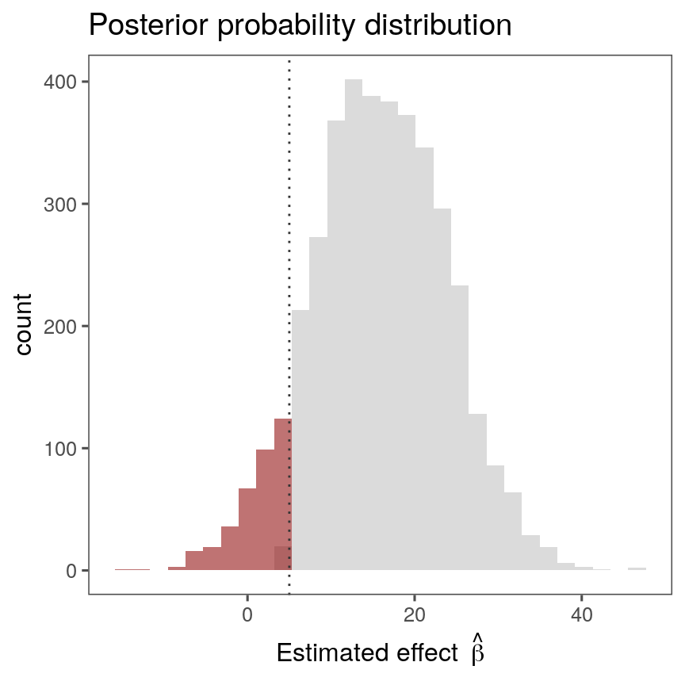

## ROPE

- Determine ROPE to assess the uncertainty of effect size (Makowski et al., 2019)
- Calculate the standardised effect size \(\delta\) from posterior: \(\delta = \frac{\beta}{\sigma}\)
- ROPE of [-0.1, 0.1] is the range of negligible effect sizes (Cohn, 1988; Kruschke, 2018).

## ROPE

- Determine ROPE to assess the uncertainty of effect size (Makowski et al., 2019)
- Calculate the standardised effect size \(\delta\) from posterior: \(\delta = \frac{\beta}{\sigma}\)
- ROPE of [-0.1, 0.1] is the range of negligible effect sizes (Cohn, 1988; Kruschke, 2018).

```r
sigma <- posterior_samples(fit_brm, pars = "sigma") %>% pull()
delta <- beta / sigma
```

```r
mean(delta) # small effect (see Cohen's d)
```

```
[1] 0.1584162
```

## ROPE

- Determine ROPE to assess the uncertainty of effect size (Makowski et al., 2019)
- Calculate the standardised effect size \(\delta\) from posterior: \(\delta = \frac{\beta}{\sigma}\)
- ROPE of [-0.1, 0.1] is the range of negligible effect sizes (Cohn, 1988; Kruschke, 2018).

```r
rope(delta, range = c(-0.1, 0.1))
```

```
# Proportion of samples inside the ROPE [-0.10, 0.10]:

inside ROPE
-----------
21.12 %
```

- The ROPE value indicates the extent to which the posterior cannot rule out a negligible effect.
- A meaningful effect size should have a small proportion of posterior samples within the ROPE.

## Final exercise: parameter evaluation

- Open the script `parameter_evaluation.R`
- Work through each line of code: complete the missing bits (`---`).
- Check out the output.

## The end

## For next session

- We will compare different models of keystroke intervals.
- Run the following models and save their posterior:
  - `gaussian_sentence.R`
  - `lognormal_sentence.R`
  - `exgaussian_sentence.R`
  - `mixture_model_sentence.R`
  - `skewnormal_sentence.R` (don’t run this one, if you don’t have time)
- Don’t worry if you don’t know what they do (yet), we just need the posterior of these models for the next session.

## References

Baayen, R. H., Davidson, D. J., & Bates, D. M. (2008). Mixed-effects modeling with crossed random effects for subjects and items. *Journal of Memory and Language*, *59*(4), 390–412.

Barr, D. J., Levy, R., Scheepers, C., & Tily, H. J. (2013). Random effects structure for confirmatory hypothesis testing: Keep it maximal. *Journal of Memory and Language*, *68*(3), 255–278.

Bates, D., Kliegl, R., Vasishth, S., & Baayen, H. (2015). Parsimonious mixed models. *arXiv Preprint arXiv:1506.04967*.

Bürkner, P.-C. (2017). brms: An R package for Bayesian multilevel models using Stan. *Journal of Statistical Software*, *80*(1), 1–28. https://doi.org/10.18637/jss.v080.i01

Bürkner, P.-C. (2018). Advanced Bayesian multilevel modeling with the R package brms. *The R Journal*, *10*(1), 395–411. https://doi.org/10.32614/RJ-2018-017

Bürkner, P.-C. (2019). Bayesian item response modeling in R with brms and Stan. *arXiv Preprint arXiv:1905.09501*.

Bürkner, P.-C., & Vuorre, M. (2019). Ordinal regression models in psychology: A tutorial. *Advances in Methods and Practices in Psychological Science*, *2*(1), 77–101.

Cohn, J. (1988). *Statistical power analysis for the behavioral sciences*. Lawrence Earlbam Associates.

Gelman, A., & Rubin, D. B. (1992). Inference from iterative simulation using multiple sequences. *Statistical Science*, *7*(4), 457–472.

Kruschke, J. K. (2010). What to believe: Bayesian methods for data analysis. *Trends in Cognitive Sciences*, *14*(7), 293–300.

Kruschke, J. K. (2011). Bayesian assessment of null values via parameter estimation and model comparison. *Perspectives on Psychological Science*, *6*(3), 299–312.

Kruschke, J. K. (2014). *Doing Bayesian data analysis: A tutorial with R, JAGS, and Stan*.

Kruschke, J. K. (2018). Rejecting or accepting parameter values in Bayesian estimation. *Advances in Methods and Practices in Psychological Science*, *1*(2), 270–280.

Makowski, D., Ben-Shachar, M. S., & Lüdecke, D. (2019). bayestestR: Describing effects and their uncertainty, existence and significance within the Bayesian framework. *Journal of Open Source Software*, *4*(40), 1541.

McElreath, R. (2016). *Statistical rethinking: A Bayesian course with examples in R and Stan*. CRC Press.